# Practice-chapter-9-11.Rmd

Min-Yao Jhu

2024-02-11

We will practice using the Chicago data set on public transit ridership. You can access it with:

```r
library(modeldata)
data("Chicago")
Chicago
```

Read about it with `?Chicago`; read more about it in [Kuhn and Johnson](https://bookdown.org/max/FES/chicago-intro.html)

```r
#?Chicago
```

```r
library(tidymodels)
library(lubridate)
library(tidyverse)
```

```r
library(ggplot2)
library(workflowsets)
library(kableExtra)
library(tidyr)
tidymodels_prefer()
```

## 1. Explore the data

1. Make a histogram of ridership.

```r
str(Chicago)
```

```
## tibble [5,698 × 50] (S3: tbl_df/tbl/data.frame)
##  $ ridership       : num [1:5698] 15.7 15.8 15.9 15.9 15.4 ...
##  $ Austin          : num [1:5698] 1.46 1.5 1.52 1.49 1.5 ...
##  $ Quincy_Wells    : num [1:5698] 8.37 8.35 8.36 7.85 7.62 ...
##  $ Belmont         : num [1:5698] 4.6 4.72 4.68 4.77 4.72 ...
##  $ Archer_35th     : num [1:5698] 2.01 2.09 2.11 2.17 2.06 ...
##  $ Oak_Park        : num [1:5698] 1.42 1.43 1.49 1.45 1.42 ...
##  $ Western         : num [1:5698] 3.32 3.34 3.36 3.36 3.27 ...
##  $ Clark_Lake      : num [1:5698] 15.6 15.7 15.6 15.7 15.6 ...
##  $ Clinton         : num [1:5698] 2.4 2.4 2.37 2.42 2.42 ...
##  $ Merchandise_Mart: num [1:5698] 6.48 6.48 6.41 6.49 5.8 ...
##  $ Irving_Park     : num [1:5698] 3.74 3.85 3.86 3.84 3.88 ...
##  $ Washington_Wells: num [1:5698] 7.56 7.58 7.62 7.36 7.09 ...
##  $ Harlem          : num [1:5698] 2.65 2.76 2.79 2.81 2.73 ...
##  $ Monroe          : num [1:5698] 5.67 6.01 5.79 5.96 5.77 ...
```

[output cut: 36 more lines]

```r
stations
```

```
##  [1] "Austin"           "Quincy_Wells"     "Belmont"          "Archer_35th"
##  [5] "Oak_Park"         "Western"          "Clark_Lake"       "Clinton"
##  [9] "Merchandise_Mart" "Irving_Park"      "Washington_Wells" "Harlem"
## [13] "Monroe"           "Polk"             "Ashland"          "Kedzie"
## [17] "Addison"          "Jefferson_Park"   "Montrose"         "California"
```

> For ease of presentation, ridership will be shown and analyzed in units of thousands of riders.

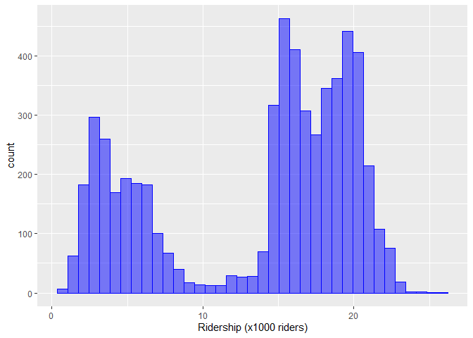

```r
y_hist <-
  ggplot(Chicago, aes(ridership)) +
  geom_histogram(binwidth = .7, fill = "blue", col = "blue", alpha = .5) +
  xlab("Ridership (x1000 riders)")

y_hist
```

2. What might be causing the two peaks. Is there a predictor variable that can account for this (or that can be used to make a new variable to account for it)?

I am not suggesting that you do regressions or plots on all variables at this time, rather that you think about what might have this kind of impact.

If you need to make a new predictor variable, go ahead.

```r
Chicago_week <- Chicago %>%
  mutate(dow = as.character(wday(ymd(date), label = T))) %>%
  mutate(weekday = as.factor(ifelse(dow %in% c("Sat","Sun"), "Weekend", "Weekday"))) %>%
  select(-c(date, dow))
Chicago_week
```

```
## # A tibble: 5,698 × 50
##    ridership Austin Quincy_Wells Belmont Archer_35th Oak_Park Western Clark_Lake
##        <dbl>  <dbl>        <dbl>   <dbl>       <dbl>    <dbl>   <dbl>      <dbl>
##  1     15.7   1.46         8.37     4.60       2.01     1.42    3.32       15.6
##  2     15.8   1.50         8.35     4.72       2.09     1.43    3.34       15.7
##  3     15.9   1.52         8.36     4.68       2.11     1.49    3.36       15.6
##  4     15.9   1.49         7.85     4.77       2.17     1.44    3.36       15.7
##  5     15.4   1.50         7.62     4.72       2.06     1.42    3.27       15.6
##  6      2.42  0.693        0.911    2.27       0.624    0.426   1.11        2.41
##  7      1.47  0.408        0.414    1.63       0.378    0.225   0.567       1.37
##  8     15.5   0.987        4.81     3.52       1.34     0.879   1.94        9.02
##  9     15.9   1.55         8.23     4.71       2.22     1.46    3.46       16.0
## 10     15.9   1.59         8.25     4.77       2.23     1.48    3.51       15.8
## # ℹ 5,688 more rows
## # ℹ 42 more variables: Clinton <dbl>, Merchandise_Mart <dbl>,
## #   Irving_Park <dbl>, Washington_Wells <dbl>, Harlem <dbl>, Monroe <dbl>,
## #   Polk <dbl>, Ashland <dbl>, Kedzie <dbl>, Addison <dbl>,
## #   Jefferson_Park <dbl>, Montrose <dbl>, California <dbl>, temp_min <dbl>,
## #   temp <dbl>, temp_max <dbl>, temp_change <dbl>, dew <dbl>, humidity <dbl>,
## #   pressure <dbl>, pressure_change <dbl>, wind <dbl>, wind_max <dbl>, …
```

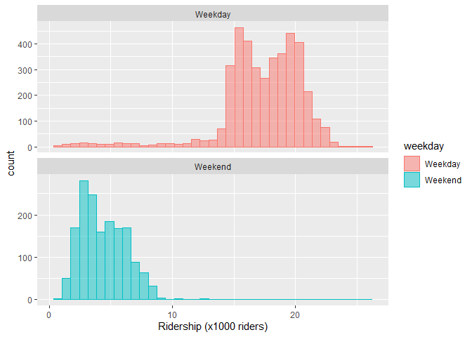

```r
fig_Chicago_week <-
  ggplot(Chicago_week, aes(ridership, fill = weekday, col = weekday)) +
  facet_wrap( ~ weekday, nrow = 2, scales = "free_y") +
  geom_histogram(binwidth = .7, alpha = .5) +
  xlab("Ridership (x1000 riders)")
fig_Chicago_week
```

> A reasonable explanation for this would be that ridership is different for weekdays than for weekends.

> This is important and necessary for explaining ridership and should be included in a model.

## 2. Training and Test

Make an 80/20 train/test split. Do you need to stratify over anything?

So that we are working on the same split, use `set.seed(010324)` in you code chunk

```r
set.seed(010324)

Chicago_split <- initial_split(Chicago_week, prop = 0.80, strata = ridership)
Chicago_train <- training(Chicago_split)
Chicago_test  <-  testing(Chicago_split)
```

```r
dim(Chicago_week)
```

```
## [1] 5698   50
```

```r
dim(Chicago_train)
```

```
## [1] 4557   50
```

```r
dim(Chicago_test)
```

```
## [1] 1141   50
```

## 3. Workflow set

Let’s compare the effectiveness of the temp and percip [sic] predictors.

### 3A

Use a workflow set (see chapter 7) to fit six models, each of which has your predictor from Q1 along with one of the following variables:

`temp_min`, `temp`, `temp_max`, `temp_change`, `percip`, `percip_max`

The formula for one of these would be something like `ridership ~ temp_min + Q1_predictor`.

```r
lm_model <- linear_reg() %>% set_engine("lm")
```

```r
weather <- list(
  temp_min = ridership ~ temp_min + weekday,
  temp = ridership ~ temp + weekday,
  temp_max = ridership ~ temp_max + weekday,
  temp_change = ridership ~ temp_change + weekday,
  percip = ridership ~ percip + weekday,
  percip_max = ridership ~ percip_max + weekday
)
```

```r
weather_models <- workflow_set(preproc = weather,
                               models = list(lm = lm_model))
weather_models
```

```
## # A workflow set/tibble: 6 × 4
##   wflow_id       info             option    result
##   <chr>          <list>           <list>    <list>
## 1 temp_min_lm    <tibble [1 × 4]> <opts[0]> <list [0]>
## 2 temp_lm        <tibble [1 × 4]> <opts[0]> <list [0]>
## 3 temp_max_lm    <tibble [1 × 4]> <opts[0]> <list [0]>
## 4 temp_change_lm <tibble [1 × 4]> <opts[0]> <list [0]>
## 5 percip_lm      <tibble [1 × 4]> <opts[0]> <list [0]>
## 6 percip_max_lm  <tibble [1 × 4]> <opts[0]> <list [0]>
```

```r
weather_models$info[[1]]
```

```
## # A tibble: 1 × 4
##   workflow   preproc model      comment
##   <list>     <chr>   <chr>      <chr>
## 1 <workflow> formula linear_reg ""
```

```r
extract_workflow(weather_models, id = "temp_lm")
```

```
## ══ Workflow ════════════════════════════════════════════════════════════════════
## Preprocessor: Formula
## Model: linear_reg()
##
## ── Preprocessor ────────────────────────────────────────────────────────────────
## ridership ~ temp + weekday
##
## ── Model ───────────────────────────────────────────────────────────────────────
## Linear Regression Model Specification (regression)
##
## Computational engine: lm
```

```r
weather_models <-
   weather_models %>%
   mutate(fit = map(info, ~ fit(.x$workflow[[1]], Chicago_train)))
weather_models
```

```
## # A workflow set/tibble: 6 × 5
##   wflow_id       info             option    result     fit
##   <chr>          <list>           <list>    <list>     <list>
## 1 temp_min_lm    <tibble [1 × 4]> <opts[0]> <list [0]> <workflow>
## 2 temp_lm        <tibble [1 × 4]> <opts[0]> <list [0]> <workflow>
## 3 temp_max_lm    <tibble [1 × 4]> <opts[0]> <list [0]> <workflow>
## 4 temp_change_lm <tibble [1 × 4]> <opts[0]> <list [0]> <workflow>
## 5 percip_lm      <tibble [1 × 4]> <opts[0]> <list [0]> <workflow>
## 6 percip_max_lm  <tibble [1 × 4]> <opts[0]> <list [0]> <workflow>
```

### 3B

Compare the model fits / predictors (this can be using any of the p-value of the predictor, R2, AIC, log-lik). Don’t worry about the test set, just compare goodness of fit when fit with the training set.

```r
weather_models %>%
  mutate(tidy=map(fit, tidy)) %>%
  unnest(tidy) %>%
  filter(str_detect(term, "temp|percip")) %>%
  arrange(p.value)
```

```
## # A tibble: 6 × 10
##   wflow_id       info     option    result fit        term    estimate std.error
##   <chr>          <list>   <list>    <list> <list>     <chr>      <dbl>     <dbl>
## 1 temp_lm        <tibble> <opts[0]> <list> <workflow> temp      0.0383   0.00217
## 2 temp_min_lm    <tibble> <opts[0]> <list> <workflow> temp_m…   0.0392   0.00223
## 3 temp_max_lm    <tibble> <opts[0]> <list> <workflow> temp_m…   0.0360   0.00205
## 4 temp_change_lm <tibble> <opts[0]> <list> <workflow> temp_c…   0.0313   0.00710
## 5 percip_max_lm  <tibble> <opts[0]> <list> <workflow> percip…   1.11     0.346
## 6 percip_lm      <tibble> <opts[0]> <list> <workflow> percip   -7.58    12.6
## # ℹ 2 more variables: statistic <dbl>, p.value <dbl>
```

## 4 Recipes

### 4A

Create a workflow recipe does the following:

- normalizes all weather and station predictors
- creates a set of PCs for the weather-related predictors, keeping enough PCs to explain 75% of the variance in the weather variables
- creates a second set of PCs for the station-related predictors, keeping enough PCs to explaining 75% of the variance in these variables

Hint: `tidy()`, `prep()`, and `bake()` methods for recipes may be helpful in examining what you have done. The help file on `recipe` is good to0.

Hint2: You can use various dplyr::select functions and regular expressions to avoid having to type out the variable names. But as a fair-warning, it took me a lot longer to figure that out than it would have to just type then out. (But next time it might be faster). I can demo.

```r
recipe(ridership ~ ., data = Chicago_train) %>%
  add_role(Austin:California, new_role = "station") %>%
  add_role(temp_min:weather_storm, new_role = "weather")
```

```
## ── Recipe ──────────────────────────────────────────────────────────────────────
```

```
## ── Inputs
```

```
## Number of variables by role
```

```
## outcome:    1
## predictor: 49
## station:   20
## weather:   18
```

```r
recipe(ridership ~ ., data = Chicago_train) %>%
  add_role(Austin:California, new_role = "station") %>%
  add_role(temp_min:weather_storm, new_role = "weather") %>%
  step_normalize(has_role("station")) %>%
  step_normalize(has_role("weather"))
```

```
## ── Recipe ──────────────────────────────────────────────────────────────────────
```

```
## ── Inputs
```

```
## Number of variables by role
```

```
## outcome:    1
## predictor: 49
## station:   20
## weather:   18
```

```
## ── Operations
```

```
## • Centering and scaling for: has_role("station")
```

```
## • Centering and scaling for: has_role("weather")
```

```r
recipe(ridership ~ ., data = Chicago_train) %>%
  add_role(Austin:California, new_role = "station") %>%
  add_role(temp_min:weather_storm, new_role = "weather") %>%
  step_normalize(has_role("station")) %>%
  step_normalize(has_role("weather")) %>%
  step_pca(has_role("station"), threshold = .75, prefix = "station_PC", id = "station_pca") %>%
  step_pca(has_role("weather"), threshold = .75, prefix = "weather_PC", id = "weather_pca")
```

```
## ── Recipe ──────────────────────────────────────────────────────────────────────
```

```
## ── Inputs
```

```
## Number of variables by role
```

```
## outcome:    1
## predictor: 49
## station:   20
## weather:   18
```

```
## ── Operations
```

```
## • Centering and scaling for: has_role("station")
```

```
## • Centering and scaling for: has_role("weather")
```

```
## • PCA extraction with: has_role("station")
```

```
## • PCA extraction with: has_role("weather")
```

```r
Chicago_rec <-
  recipe(ridership ~ ., data = Chicago_train) %>%
  add_role(Austin:California, new_role = "station") %>%
  add_role(temp_min:weather_storm, new_role = "weather") %>%
  step_normalize(has_role("station")) %>%
  step_normalize(has_role("weather")) %>%
  step_pca(has_role("station"), threshold = .75, prefix = "station_PC", id = "station_pca") %>%
  step_pca(has_role("weather"), threshold = .75, prefix = "weather_PC", id = "weather_pca")

Chicago_rec
```

```
## ── Recipe ──────────────────────────────────────────────────────────────────────
```

```
## ── Inputs
```

```
## Number of variables by role
```

```
## outcome:    1
## predictor: 49
## station:   20
## weather:   18
```

```
## ── Operations
```

```
## • Centering and scaling for: has_role("station")
```

```
## • Centering and scaling for: has_role("weather")
```

```
## • PCA extraction with: has_role("station")
```

```
## • PCA extraction with: has_role("weather")
```

```r
tidy(Chicago_rec)
```

```
## # A tibble: 4 × 6
##   number operation type      trained skip  id
##    <int> <chr>     <chr>     <lgl>   <lgl> <chr>
## 1      1 step      normalize FALSE   FALSE normalize_viLm0
## 2      2 step      normalize FALSE   FALSE normalize_LApdr
## 3      3 step      pca       FALSE   FALSE station_pca
## 4      4 step      pca       FALSE   FALSE weather_pca
```

### 4B

Use the recipe from 4A to fit a linear regression of ridership on the new PCs and all remaining predictors (i.e. those not used in making the PCs). Use the training data.

```r
lm_wflow <-
  workflow() %>%
  add_model(lm_model) %>%
  add_recipe(Chicago_rec)

lm_fit <- fit(lm_wflow, Chicago_train)

tidy(lm_fit)
```

```
## # A tibble: 19 × 5
##    term            estimate std.error statistic    p.value
##    <chr>              <dbl>     <dbl>     <dbl>      <dbl>
##  1 (Intercept)      15.9       0.0966  164.      0
##  2 Blackhawks_Away   0.284     0.133     2.14    3.25e-  2
##  3 Blackhawks_Home   0.434     0.136     3.19    1.43e-  3
##  4 Bulls_Away        0.0213    0.133     0.160   8.73e-  1
##  5 Bulls_Home        0.520     0.133     3.90    9.73e-  5
##  6 Bears_Away       -0.175     0.262    -0.666   5.05e-  1
##  7 Bears_Home        0.0185    0.243     0.0762  9.39e-  1
##  8 WhiteSox_Away    -0.0440    0.114    -0.384   7.01e-  1
##  9 WhiteSox_Home    NA        NA        NA      NA
## 10 Cubs_Away        NA        NA        NA      NA
## 11 Cubs_Home        NA        NA        NA      NA
## 12 weekdayWeekend   -8.24      0.190   -43.3     0
## 13 station_PC1       0.552     0.0197   28.0     1.15e-159
## 14 weather_PC1       0.298     0.0271   11.0     1.10e- 27
## 15 weather_PC2      -0.0125    0.0211   -0.592   5.54e-  1
## 16 weather_PC3       0.0108    0.0272    0.396   6.92e-  1
## 17 weather_PC4       0.0265    0.0313    0.846   3.98e-  1
## 18 weather_PC5      -0.0500    0.0385   -1.30    1.94e-  1
## 19 weather_PC6       0.0373    0.0404    0.925   3.55e-  1
```

```r
tidy(lm_fit) %>% select(term, p.value)
```

```
## # A tibble: 19 × 2
##    term               p.value
##    <chr>                <dbl>
##  1 (Intercept)      0
##  2 Blackhawks_Away  3.25e-  2
##  3 Blackhawks_Home  1.43e-  3
##  4 Bulls_Away       8.73e-  1
##  5 Bulls_Home       9.73e-  5
##  6 Bears_Away       5.05e-  1
##  7 Bears_Home       9.39e-  1
##  8 WhiteSox_Away    7.01e-  1
##  9 WhiteSox_Home   NA
## 10 Cubs_Away       NA
## 11 Cubs_Home       NA
## 12 weekdayWeekend   0
## 13 station_PC1      1.15e-159
## 14 weather_PC1      1.10e- 27
## 15 weather_PC2      5.54e-  1
## 16 weather_PC3      6.92e-  1
## 17 weather_PC4      3.98e-  1
## 18 weather_PC5      1.94e-  1
## 19 weather_PC6      3.55e-  1
```

> remove date

### 4C

Use the fit from 4B to predict ridership in the test data. Evaluate the predictions.

```r
str(Chicago_test)
```

```
## tibble [1,141 × 50] (S3: tbl_df/tbl/data.frame)
##  $ ridership       : num [1:1141] 2.48 1.56 15.58 15.79 16.16 ...
##  $ Austin          : num [1:1141] 0.663 0.411 1.592 1.583 1.603 ...
##  $ Quincy_Wells    : num [1:1141] 0.914 0.454 8.165 7.876 8.13 ...
##  $ Belmont         : num [1:1141] 2.28 1.64 4.69 4.69 4.77 ...
##  $ Archer_35th     : num [1:1141] 0.643 0.337 2.211 2.219 2.206 ...
##  $ Oak_Park        : num [1:1141] 0.402 0.212 1.479 1.435 1.45 ...
##  $ Western         : num [1:1141] 1.037 0.562 3.425 3.517 3.447 ...
##  $ Clark_Lake      : num [1:1141] 2.32 1.49 15.92 16.16 15.69 ...
##  $ Clinton         : num [1:1141] 0.78 0.579 2.426 2.203 2.367 ...
##  $ Merchandise_Mart: num [1:1141] 0.858 0.267 6.407 6.254 6.032 ...
##  $ Irving_Park     : num [1:1141] 1.75 1.18 3.88 3.77 3.75 ...
##  $ Washington_Wells: num [1:1141] 0.738 0.34 7.521 7.354 7.267 ...
##  $ Harlem          : num [1:1141] 1.015 0.626 2.79 2.771 2.809 ...
##  $ Monroe          : num [1:1141] 1.066 0.671 6.18 6.079 6.269 ...
```

[output cut: 36 more lines]

```r
Chicago_test_nor <- Chicago_test %>% select(-ridership)
str(Chicago_test_nor)
```

```
## tibble [1,141 × 49] (S3: tbl_df/tbl/data.frame)
##  $ Austin          : num [1:1141] 0.663 0.411 1.592 1.583 1.603 ...
##  $ Quincy_Wells    : num [1:1141] 0.914 0.454 8.165 7.876 8.13 ...
##  $ Belmont         : num [1:1141] 2.28 1.64 4.69 4.69 4.77 ...
##  $ Archer_35th     : num [1:1141] 0.643 0.337 2.211 2.219 2.206 ...
##  $ Oak_Park        : num [1:1141] 0.402 0.212 1.479 1.435 1.45 ...
##  $ Western         : num [1:1141] 1.037 0.562 3.425 3.517 3.447 ...
##  $ Clark_Lake      : num [1:1141] 2.32 1.49 15.92 16.16 15.69 ...
##  $ Clinton         : num [1:1141] 0.78 0.579 2.426 2.203 2.367 ...
##  $ Merchandise_Mart: num [1:1141] 0.858 0.267 6.407 6.254 6.032 ...
##  $ Irving_Park     : num [1:1141] 1.75 1.18 3.88 3.77 3.75 ...
##  $ Washington_Wells: num [1:1141] 0.738 0.34 7.521 7.354 7.267 ...
##  $ Harlem          : num [1:1141] 1.015 0.626 2.79 2.771 2.809 ...
##  $ Monroe          : num [1:1141] 1.066 0.671 6.18 6.079 6.269 ...
##  $ Polk            : num [1:1141] 0.01 0 2.44 2.41 2.51 ...
```

[output cut: 35 more lines]

```r
Chicago_test_onlyr <- Chicago_test %>% select(ridership,weekday)
str(Chicago_test_onlyr)
```

```
## tibble [1,141 × 2] (S3: tbl_df/tbl/data.frame)
##  $ ridership: num [1:1141] 2.48 1.56 15.58 15.79 16.16 ...
##  $ weekday  : Factor w/ 2 levels "Weekday","Weekend": 2 2 1 1 1 2 1 2 2 2 ...
```

```r
predicted_r <- predict(lm_fit, Chicago_test_nor)
predicted_r
```

```
## # A tibble: 1,141 × 1
##    .pred
##    <dbl>
##  1  2.69
##  2  2.35
##  3 16.3
##  4 16.3
##  5 16.2
##  6  3.69
##  7 16.4
##  8  3.13
##  9  3.11
## 10  1.95
## # ℹ 1,131 more rows
```

```r
chicago_test_predictions <- bind_cols(predicted_r, Chicago_test_onlyr)
chicago_test_predictions
```

```
## # A tibble: 1,141 × 3
##    .pred ridership weekday
##    <dbl>     <dbl> <fct>
##  1  2.69      2.48 Weekend
##  2  2.35      1.56 Weekend
##  3 16.3      15.6  Weekday
##  4 16.3      15.8  Weekday
##  5 16.2      16.2  Weekday
##  6  3.69      2.76 Weekend
##  7 16.4      16.2  Weekday
##  8  3.13      3    Weekend
##  9  3.11      2.70 Weekend
## 10  1.95      1.71 Weekend
## # ℹ 1,131 more rows
```

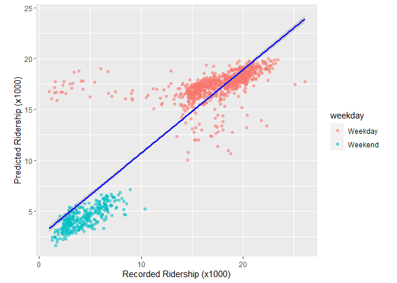

```r
chicago_test_predictions |>
  ggplot(aes(x = ridership, y = .pred, col = weekday)) +
  geom_point(alpha = 0.5) +
  labs(y = "Predicted Ridership (x1000)", x = "Recorded Ridership (x1000)") +
  geom_smooth(method = lm, formula = y ~ x, color = "blue") +
  coord_equal()
```

Return to the Chicago data and Q4 from the previous Chicago assignment.

For Q4 we were predicting ridership from weather PCs, station PCs, and remaining predictors.

Use Cross-fold validation and the model selection techniques shown in chapter 12 to compare models with:

1. All PCs and remaining predictors (same as Q4) optional: compare random forest and lm for this full data set

Step 1: Setting Up Cross-Fold Validation

```r
set.seed(123) # For reproducibility
cv_folds <- vfold_cv(Chicago_train, v = 10)
```

Step 2: Specifying Models

```r
# Linear Model Specification
lm_spec <- linear_reg() %>%
  set_engine("lm")

# Random Forest Specification
rf_spec <- rand_forest(trees = 1000) %>%
  set_engine("ranger") %>%
  set_mode("regression")
```

Step 3: Workflow and Model Comparison

```r
# Create workflows
lm_workflow <-
  workflow() %>%
  add_model(lm_spec) %>%
  add_recipe(Chicago_rec)

rf_workflow <-
  workflow() %>%
  add_model(rf_spec) %>%
  add_recipe(Chicago_rec)

# Compare models using cross-validation
keep_pred <- control_resamples(save_pred = TRUE, save_workflow = TRUE)

set.seed(1003)

lm_res <-
  lm_workflow %>%
  fit_resamples(resamples = cv_folds, control = keep_pred)
```

```
## → A | warning: prediction from rank-deficient fit; consider predict(., rankdeficient="NA")
```

[output not shown]

```r
rf_res <-
  rf_workflow %>%
  fit_resamples(resamples = cv_folds, control = keep_pred)

collect_metrics(lm_res)
```

```
## # A tibble: 2 × 6
##   .metric .estimator  mean     n std_err .config
##   <chr>   <chr>      <dbl> <int>   <dbl> <chr>
## 1 rmse    standard   2.70      1      NA Preprocessor1_Model1
## 2 rsq     standard   0.834     1      NA Preprocessor1_Model1
```

```r
collect_metrics(rf_res)
```

```
## # A tibble: 2 × 6
##   .metric .estimator  mean     n std_err .config
##   <chr>   <chr>      <dbl> <int>   <dbl> <chr>
## 1 rmse    standard   2.39     10 0.0722  Preprocessor1_Model1
## 2 rsq     standard   0.866    10 0.00786 Preprocessor1_Model1
```

```r
Chicago_rec1 <-
  recipe(ridership ~ ., data = Chicago_train) %>%
  add_role(Austin:California, new_role = "station") %>%
  add_role(temp_min:weather_storm, new_role = "weather") %>%
  step_normalize(has_role("station")) %>%
  step_normalize(has_role("weather")) %>%
  step_pca(has_role("station"), threshold = .75, prefix = "station_PC", id = "station_pca") %>%
  step_pca(has_role("weather"), threshold = .75, prefix = "weather_PC", id = "weather_pca")

Chicago_rec1
```

```
## ── Recipe ──────────────────────────────────────────────────────────────────────
```

```
## ── Inputs
```

```
## Number of variables by role
```

```
## outcome:    1
## predictor: 49
## station:   20
## weather:   18
```

```
## ── Operations
```

```
## • Centering and scaling for: has_role("station")
```

```
## • Centering and scaling for: has_role("weather")
```

```
## • PCA extraction with: has_role("station")
```

```
## • PCA extraction with: has_role("weather")
```

2. The PCs + the weekend variable (no sports team data)

```r
str(Chicago_train)
```

```
## tibble [4,557 × 50] (S3: tbl_df/tbl/data.frame)
##  $ ridership       : num [1:4557] 2.42 1.47 2.43 1.79 2.44 ...
##  $ Austin          : num [1:4557] 0.693 0.408 0.677 0.458 0.632 0.39 0.679 0.428 0.393 0.39 ...
##  $ Quincy_Wells    : num [1:4557] 0.911 0.414 0.914 0.449 0.843 0.532 0.942 0.513 0.509 0.541 ...
##  $ Belmont         : num [1:4557] 2.27 1.63 2.32 1.64 2.22 ...
##  $ Archer_35th     : num [1:4557] 0.624 0.378 0.646 0.304 0.698 0.347 0.706 0.377 0.368 0.32 ...
##  $ Oak_Park        : num [1:4557] 0.426 0.225 0.404 0.252 0.4 0.23 0.401 0.209 0.252 0.242 ...
##  $ Western         : num [1:4557] 1.111 0.567 1.063 0.56 1.04 ...
##  $ Clark_Lake      : num [1:4557] 2.41 1.37 2.42 1.47 2.48 ...
##  $ Clinton         : num [1:4557] 0.814 0.583 0.764 0.632 0.73 0.637 0.742 0.726 0.647 0.584 ...
##  $ Merchandise_Mart: num [1:4557] 0.858 0.268 1.598 0.787 0.867 ...
##  $ Irving_Park     : num [1:4557] 1.74 1.16 1.62 1.12 1.56 ...
##  $ Washington_Wells: num [1:4557] 0.786 0.298 0.687 0.311 0.67 0.357 0.731 0.333 0.395 0.396 ...
##  $ Harlem          : num [1:4557] 1.034 0.642 1.002 0.656 1.031 ...
##  $ Monroe          : num [1:4557] 1.044 0.53 1.109 0.553 1.093 ...
```

[output cut: 36 more lines]

use “update_role” to remove “sports_team” from predictors

```r
Chicago_rec2 <-
  recipe(ridership ~ ., data = Chicago_train) %>%
  update_role(Blackhawks_Away:Cubs_Home, new_role = "sports_team") %>%
  add_role(Austin:California, new_role = "station") %>%
  add_role(temp_min:weather_storm, new_role = "weather") %>%
  step_normalize(has_role("station")) %>%
  step_normalize(has_role("weather")) %>%
  step_pca(has_role("station"), threshold = .75, prefix = "station_PC", id = "station_pca") %>%
  step_pca(has_role("weather"), threshold = .75, prefix = "weather_PC", id = "weather_pca")

Chicago_rec2
```

```
## ── Recipe ──────────────────────────────────────────────────────────────────────
```

```
## ── Inputs
```

```
## Number of variables by role
```

```
## outcome:      1
## predictor:   39
## station:     20
## weather:     18
## sports_team: 10
```

```
## ── Operations
```

```
## • Centering and scaling for: has_role("station")
```

```
## • Centering and scaling for: has_role("weather")
```

```
## • PCA extraction with: has_role("station")
```

```
## • PCA extraction with: has_role("weather")
```

3. 1 weather PC, 1 station PC, + the weekend variable

> select only the top 1 PC

```r
Chicago_rec3 <-
  recipe(ridership ~ ., data = Chicago_train) %>%
  update_role(Blackhawks_Away:Cubs_Home, new_role = "sports_team") %>%
  add_role(Austin:California, new_role = "station") %>%
  add_role(temp_min:weather_storm, new_role = "weather") %>%
  step_normalize(has_role("station")) %>%
  step_normalize(has_role("weather")) %>%
  step_pca(has_role("station"), num_comp = 1, prefix = "station_PC", id = "station_pca") %>%
  step_pca(has_role("weather"), num_comp = 1, prefix = "weather_PC", id = "weather_pca")

Chicago_rec3
```

```
## ── Recipe ──────────────────────────────────────────────────────────────────────
```

```
## ── Inputs
```

```
## Number of variables by role
```

```
## outcome:      1
## predictor:   39
## station:     20
## weather:     18
## sports_team: 10
```

```
## ── Operations
```

```
## • Centering and scaling for: has_role("station")
```

```
## • Centering and scaling for: has_role("weather")
```

```
## • PCA extraction with: has_role("station")
```

```
## • PCA extraction with: has_role("weather")
```

4. 1 weather PC + the weekend variable

use “update_role” to remove “station” from predictors

```r
Chicago_rec4 <-
  recipe(ridership ~ ., data = Chicago_train) %>%
  update_role(Blackhawks_Away:Cubs_Home, new_role = "sports_team") %>%
  update_role(Austin:California, new_role = "station") %>%
  add_role(temp_min:weather_storm, new_role = "weather") %>%
  step_normalize(has_role("weather")) %>%
  step_pca(has_role("weather"), num_comp = 1, prefix = "weather_PC", id = "weather_pca")

Chicago_rec4
```

```
## ── Recipe ──────────────────────────────────────────────────────────────────────
```

```
## ── Inputs
```

```
## Number of variables by role
```

```
## outcome:      1
## predictor:   19
## station:     20
## weather:     18
## sports_team: 10
```

```
## ── Operations
```

```
## • Centering and scaling for: has_role("weather")
```

```
## • PCA extraction with: has_role("weather")
```

5. 1 station PC + the weekend variable

use “update_role” to remove “weather” from predictors

```r
Chicago_rec5 <-
  recipe(ridership ~ ., data = Chicago_train) %>%
  update_role(Blackhawks_Away:Cubs_Home, new_role = "sports_team") %>%
  add_role(Austin:California, new_role = "station") %>%
  update_role(temp_min:weather_storm, new_role = "weather") %>%
  step_normalize(has_role("station")) %>%
  step_pca(has_role("station"), num_comp = 1, prefix = "station_PC", id = "station_pca")

Chicago_rec5
```

```
## ── Recipe ──────────────────────────────────────────────────────────────────────
```

```
## ── Inputs
```

```
## Number of variables by role
```

```
## outcome:      1
## predictor:   21
## station:     20
## weather:     18
## sports_team: 10
```

```
## ── Operations
```

```
## • Centering and scaling for: has_role("station")
```

```
## • PCA extraction with: has_role("station")
```

6. the weekend variable only

use “update_role” to remove “weather” & “station” from predictors

```r
Chicago_rec6 <-
  recipe(ridership ~ ., data = Chicago_train) %>%
  update_role(Blackhawks_Away:Cubs_Home, new_role = "sports_team") %>%
  update_role(Austin:California, new_role = "station") %>%
  update_role(temp_min:weather_storm, new_role = "weather")

Chicago_rec6
```

```
## ── Recipe ──────────────────────────────────────────────────────────────────────
```

```
## ── Inputs
```

```
## Number of variables by role
```

```
## outcome:      1
## predictor:    1
## station:     20
## weather:     18
## sports_team: 10
```

```r
library(tidymodels)
tidymodels_prefer()

preproc <-
  list(model1 = Chicago_rec1,
       model2 = Chicago_rec2,
       model3 = Chicago_rec3,
       model4 = Chicago_rec4,
       model5 = Chicago_rec5,
       model6 = Chicago_rec6
  )

lm_models <- workflow_set(preproc, list(lm = linear_reg()), cross = FALSE)
lm_models
```

```
## # A workflow set/tibble: 6 × 4
##   wflow_id  info             option    result
##   <chr>     <list>           <list>    <list>
## 1 model1_lm <tibble [1 × 4]> <opts[0]> <list [0]>
## 2 model2_lm <tibble [1 × 4]> <opts[0]> <list [0]>
## 3 model3_lm <tibble [1 × 4]> <opts[0]> <list [0]>
## 4 model4_lm <tibble [1 × 4]> <opts[0]> <list [0]>
## 5 model5_lm <tibble [1 × 4]> <opts[0]> <list [0]>
## 6 model6_lm <tibble [1 × 4]> <opts[0]> <list [0]>
```

```r
lm_models <-
  lm_models %>%
  workflow_map("fit_resamples",
               # Options to `workflow_map()`:
               seed = 1101, verbose = TRUE,
               # Options to `fit_resamples()`:
               resamples = cv_folds, control = keep_pred)
```

```
## i 1 of 6 resampling: model1_lm
```

```
## → A | warning: prediction from rank-deficient fit; consider predict(., rankdeficient="NA")
```

[output not shown]

```
## ✔ 1 of 6 resampling: model1_lm (1.5s)
## i 2 of 6 resampling: model2_lm
## ✔ 2 of 6 resampling: model2_lm (1s)
## i 3 of 6 resampling: model3_lm
## ✔ 3 of 6 resampling: model3_lm (950ms)
## i 4 of 6 resampling: model4_lm
## ✔ 4 of 6 resampling: model4_lm (791ms)
## i 5 of 6 resampling: model5_lm
## ✔ 5 of 6 resampling: model5_lm (730ms)
## i 6 of 6 resampling: model6_lm
## ✔ 6 of 6 resampling: model6_lm (460ms)
```

```r
lm_models
```

```
## # A workflow set/tibble: 6 × 4
##   wflow_id  info             option    result
##   <chr>     <list>           <list>    <list>
## 1 model1_lm <tibble [1 × 4]> <opts[2]> <rsmp[+]>
## 2 model2_lm <tibble [1 × 4]> <opts[2]> <rsmp[+]>
## 3 model3_lm <tibble [1 × 4]> <opts[2]> <rsmp[+]>
## 4 model4_lm <tibble [1 × 4]> <opts[2]> <rsmp[+]>
## 5 model5_lm <tibble [1 × 4]> <opts[2]> <rsmp[+]>
## 6 model6_lm <tibble [1 × 4]> <opts[2]> <rsmp[+]>
```

```r
collect_metrics(lm_models) %>%
  filter(.metric == "rmse")
```

```
## # A tibble: 6 × 9
##   wflow_id  .config         preproc model .metric .estimator  mean     n std_err
##   <chr>     <chr>           <chr>   <chr> <chr>   <chr>      <dbl> <int>   <dbl>
## 1 model1_lm Preprocessor1_… recipe  line… rmse    standard    2.70     1 NA
## 2 model2_lm Preprocessor1_… recipe  line… rmse    standard    2.66    10  0.0606
## 3 model3_lm Preprocessor1_… recipe  line… rmse    standard    2.66    10  0.0577
## 4 model4_lm Preprocessor1_… recipe  line… rmse    standard    2.89    10  0.0554
## 5 model5_lm Preprocessor1_… recipe  line… rmse    standard    2.70    10  0.0608
## 6 model6_lm Preprocessor1_… recipe  line… rmse    standard    2.98    10  0.0627
```

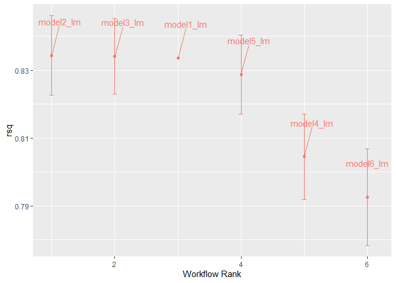

```r
library(ggrepel)
autoplot(lm_models, metric = "rsq") +
  geom_text_repel(aes(label = wflow_id), nudge_x = 1/8, nudge_y = 1/100) +
  theme(legend.position = "none")
```

```r
rsq_indiv_estimates <-
  collect_metrics(lm_models, summarize = FALSE) %>%
  filter(.metric == "rsq")

rsq_wider <-
  rsq_indiv_estimates %>%
  select(wflow_id, .estimate, id) %>%
  pivot_wider(id_cols = "id", names_from = "wflow_id", values_from = ".estimate")

rsq_wider
```

```
## # A tibble: 10 × 7
##    id     model1_lm model2_lm model3_lm model4_lm model5_lm model6_lm
##    <chr>      <dbl>     <dbl>     <dbl>     <dbl>     <dbl>     <dbl>
##  1 Fold01     0.834     0.833     0.833     0.805     0.823     0.786
##  2 Fold02    NA         0.828     0.828     0.800     0.828     0.795
##  3 Fold03    NA         0.842     0.842     0.819     0.835     0.804
##  4 Fold04    NA         0.861     0.861     0.836     0.852     0.825
##  5 Fold05    NA         0.851     0.851     0.815     0.848     0.806
##  6 Fold06    NA         0.822     0.823     0.803     0.815     0.782
##  7 Fold07    NA         0.871     0.866     0.835     0.865     0.833
##  8 Fold08    NA         0.795     0.796     0.756     0.787     0.737
##  9 Fold09    NA         0.823     0.824     0.797     0.820     0.788
## 10 Fold10    NA         0.817     0.817     0.781     0.816     0.770
```

```r
corrr::correlate(rsq_wider %>% select(-id), quiet = TRUE)
```

```
## # A tibble: 6 × 7
##   term      model1_lm model2_lm model3_lm model4_lm model5_lm model6_lm
##   <chr>         <dbl>     <dbl>     <dbl>     <dbl>     <dbl>     <dbl>
## 1 model1_lm        NA    NA        NA        NA        NA        NA
## 2 model2_lm        NA    NA         0.998     0.959     0.988     0.971
## 3 model3_lm        NA     0.998    NA         0.967     0.986     0.974
## 4 model4_lm        NA     0.959     0.967    NA         0.941     0.979
## 5 model5_lm        NA     0.988     0.986     0.941    NA         0.977
## 6 model6_lm        NA     0.971     0.974     0.979     0.977    NA
```

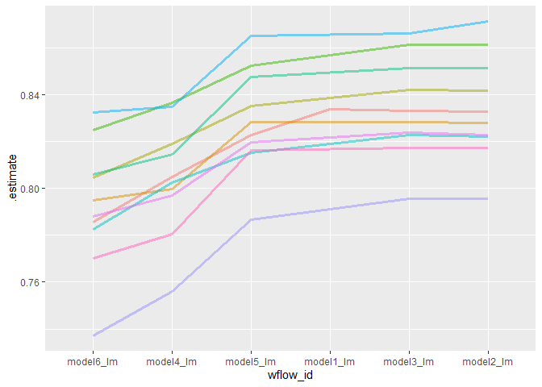

```r
rsq_indiv_estimates %>%
  mutate(wflow_id = reorder(wflow_id, .estimate)) %>%
  ggplot(aes(x = wflow_id, y = .estimate, group = id, color = id)) +
  geom_line(alpha = .5, linewidth = 1.25) +
  theme(legend.position = "none")
```

1. All PCs and remaining predictors (same as Q4)
2. The PCs + the weekend variable (no sports team data)
3. 1 weather PC, 1 station PC, + the weekend variable
4. 1 weather PC + the weekend variable
5. 1 station PC + the weekend variable
6. the weekend variable only

Here is how I set up the weekend variable:

```r
#Chicago <- Chicago %>%
#  mutate(weekend = timeDate::isBizday(timeDate::as.timeDate(date)))
```